# Homework 2: Multiple Regressions and Potential Outcomes

STA 235H

Due on Sep. 23rd, 11:59pm

# Note

- This document will serve as your Answer Key for Homework 2. Please check the rubric to understand how the assignment is graded.
- All automatically-graded questions will receive full credit if correct or 0 points if they are not correct. The only exception is with multiple answers were points are allocated proportionally.
- Inconsistencies between code and answers will be discounted (i.e. if an answer is correct, but the code used to get to that answer is not, that question will be discounted).
- R scripts and PDF files will also be checked for completeness. If they are not complete (i.e. do not contain the code/output requested), a discount will apply.
- After you receive your graded assignment, you will have one week to submit re-grading requests. Please compare your graded submission with this answer key and fill out the re-grading form with your specific request.

# Task 1 - Introductory Questions

**1) If we have the following model to explain the revenue of a company:**
$$\log(Revenue) = \beta_0 +
\beta_1 Industry + \beta_2 InitialInvestment + \beta_3
(InitialInvestment)^2 + \beta_4 CEOExperience + \varepsilon$$
**Which of the following statements is/are TRUE?**(4 points)

1. The association between CEO experience and revenue is not constant and changes depending on the CEO’s initial experience, holding industry and initial investment constant.
2. Revenue and Initial Investment will be positively correlated (holding other variables constant) if $\beta_2$ is positive.
3. If $\beta_3$ is not statistically significant, we cannot argue that there is a quadratic relationship between revenue and initial investment.
4. $\beta_0$ represents the average revenue when all other covariates are set to 0.
5. If $\beta_3<0$, it is evidence that there are diminishing returns to initial investment on revenue, holding other variables constant.

Answer:

C and E

**2) You are working in revenue management for an airline, and need to decide whether to apply a promotion for a specific route in the following week. This promotion would decrease prices by 15% in that route for all customers. Your outcome of interest, *PriceIncrease*, is whether your sales increase that week (1) or not (0) with respect to the previous one.**

**You remember your causal inference training and decide to put it into practice. In this case, which are your potential outcomes?**(2 points)

1. *PriceIncrease=1* and *PriceIncrease=0*.
2. *PriceIncrease=1* if I apply the discount, *PriceIncrease=0* if I apply the discount, *PriceIncrease=1* if I don’t apply the discount, *PriceIncrease=0* if I don’t apply the discount.
3. *PriceIncrease* if I apply the discount, *PriceIncrease* if I don’t apply the discount.
4. *PriceIncrease=1* and *PriceIncrease=0* if I apply the discount.

Answer:

C

**3) Which of the following statements represent the fundamental problem of causal inference? Select all that apply** (2 points)

1. “If we want to know the effect of a marketing campaign, we cannot observe what would have happened if we hadn’t put it in place”
2. “We cannot generalize the findings from a small sample to a larger population, because most of the time, they are not representative”
3. “In social sciences, we cannot observe individual causal effects”
4. “Traditional regressions impose a linear functional form that it is not usually realistic”

Answer:

A and C

**4) Which of the following statements is/are NOT TRUE regarding Linear Probability Models (LPM)?** (4 points)

a) An LPM is a traditional linear regression with a binary outcome  
b) LPM performs better than logistic regressions are prediction because they are simpler.  
c) The intercept in a LPM captures the average probability of an event happening (Y=1) for my entire sample.  
d) Generally, we shouldn’t use LPM if we have small samples.

Answer: B and C

**5) Thinking about the following model:**

$$\log\left(Income\right)=\beta_0+\beta_1CollegeMajor+\beta_2SAT+\beta_3ParentsIncome+\varepsilon$$

**Is the following interpretation of $\beta_2$ TRUE?** (2 points)

“One additional point in the SAT is associated with a $\beta_2\times100$ percentage point increase in income, holding college major and parental income constant”.

Answer:

No. The interpretation should say “percentage” and not “percentage points”.

# Task 2 - Outliers and Polynomials: Keep Austin Weird

In this task, we will be using recently scraped data from Zillow, which contains information about houses that are in the market in Austin. You can get the data [here](https://raw.githubusercontent.com/maibennett/sta235/main/exampleSite/content/Assignments/Homework/HW2/data/AustinBuyHouses.csv):

```r
austin <- read.csv("https://raw.githubusercontent.com/maibennett/sta235/main/exampleSite/content/Assignments/Homework/HW2/data/AustinBuyHouses.csv")
```

Some variables from this dataset that we might be interesting:

- `area`: Area of the house, in sqft.
- `baths`: Number of baths.
- `beds`: Number of bedrooms.
- `zestimate`: Zillow price estimate.
- `price`: Price in dollars (formatted as a string).
- `unformattedPrice`: Price in dollars(formatted as numeric).

Just as in our previous assignment, we would like to look at the association between different characteristics of a property and their sales price, but this time, we will do some deeper data inspection.

**1) Drop missing values in area and price to create a new dataframe `austin_clean`. Additionally, create a new price variable names price000s that measures price in thousands of dollars (instead of dollars). How many observations do we have left?** (Note: Use `unformattedPrice` to have a numeric version of price) (1 points)

Answer:

```r
austin_clean <- austin %>% filter(!is.na(area) & !is.na(unformattedPrice))
austin_clean <- austin_clean %>% mutate(price000s = unformattedPrice/1000)

nrow(austin_clean)
```

```
## [1] 789
```

**2) You know that the size of a house is clearly associated to price, but you don’t think that relationship is linear. Fit a model that captures a quadratic relationship between area and price (no need to include additional covariates).**

**a) Show your code for the regression previously discussed. Include the code for dropping variables and creating price000s (from 2.1).** (2 points)

Answer:

```r
austin_clean <- austin %>% filter(!is.na(area) & !is.na(unformattedPrice))
austin_clean <- austin_clean %>% mutate(price000s = unformattedPrice/1000)

lm_quad <- lm(price000s ~ area + I(area^2), data = austin_clean)

summary(lm_quad)
```

```
##
## Call:
## lm(formula = price000s ~ area + I(area^2), data = austin_clean)
##
## Residuals:
##     Min      1Q  Median      3Q     Max
## -8217.9  -329.4   -42.3   184.1 12018.4
##
## Coefficients:
##                   Estimate     Std. Error t value             Pr(>|t|)
## (Intercept) -277.662460556   95.811288696  -2.898              0.00386 **
## area           0.503117567    0.059998507   8.386 0.000000000000000233 ***
## I(area^2)      0.000041988    0.000006067   6.921 0.000000000009324054 ***
## ---
## Signif. codes:  0 '***' 0.001 '**' 0.01 '*' 0.05 '.' 0.1 ' ' 1
##
## Residual standard error: 981.8 on 786 degrees of freedom
## Multiple R-squared:  0.577,  Adjusted R-squared:  0.5759
## F-statistic:   536 on 2 and 786 DF,  p-value: < 0.00000000000000022
```

```r
round(lm_quad$coefficients["area"] + 2*lm_quad$coefficients["I(area^2)"]*2000,2)
```

```
## area
## 0.67
```

2 points: Drops missing values, creates price000s correctly, and fits the correct regression.

1 point: Problems with one of the previous items.

0 points: Problems with two or more of the previous items.

**b) How does price change when you compare a house with 2,000 sqft vs one with 2,001 sqft?** (3 points)

Answer:

0.67

**c) Interpret the previous association** (5 points)

Answer:

On average, for a one-sqft increase in area from 2,000 to 2,001 sqft, listing price of a house increases by M$0.67.

5 points: Correct point estimate and interpretation (units, “on average”, doesn’t say “holding other variables constant”)

3 point: Problems with one of the previous items.

0 points: Problems with two or more of the previous items.

**3) You show these results to your boss, but she doesn’t seem too sure. She thinks that the market is highly heterogeneous and she wants you to look deeper into this. You remember your STA 235H training, and decide to look for outliers!**

**a) First, let’s look at some outliers for `area`. To help you visualize, make a scatter plot of area (X) and price (Y), and create a variable `outlier` that will capture observations with area>10,000 sqft. How many outliers do we have in this case?** (2 points)

Answer:

```r
austin_clean <- austin_clean %>% mutate(outlier = ifelse(area >10000,1,0))

austin_clean %>% select(outlier) %>% table()
```

```
## .
##   0   1
## 786   3
```

3 outliers

**b) Run the same regression in 2.2, but this time without outliers. Show your code (data and regression).** (5 points)

Answer:

```r
austin_wo_outliers <- austin_clean %>% filter(outlier==0)

lm_quad2 <- lm(price000s ~ area + I(area^2), data = austin_wo_outliers)

summary(lm_quad2)
```

```
##
## Call:
## lm(formula = price000s ~ area + I(area^2), data = austin_wo_outliers)
##
## Residuals:
##     Min      1Q  Median      3Q     Max
## -6113.1  -223.0   -60.0   107.9  9046.3
##
## Coefficients:
##                  Estimate    Std. Error t value             Pr(>|t|)
## (Intercept) 337.357284794  94.835419383   3.557             0.000397 ***
## area         -0.090035269   0.068582743  -1.313             0.189636
## I(area^2)     0.000152228   0.000009745  15.621 < 0.0000000000000002 ***
## ---
## Signif. codes:  0 '***' 0.001 '**' 0.01 '*' 0.05 '.' 0.1 ' ' 1
##
## Residual standard error: 835.4 on 783 degrees of freedom
## Multiple R-squared:  0.6257, Adjusted R-squared:  0.6247
## F-statistic: 654.4 on 2 and 783 DF,  p-value: < 0.00000000000000022
```

5 points: Created the correct dataframe without outliers, and fits the correct regression.

3 points: Problems with one of the previous items.

0 points: Problems with two of the previous items.

**c) How does price change when you compare a house with 2,000 sqft vs one with 2,0001 sqft?** (3 points)

```r
round(lm_quad2$coefficients["area"] + 2*lm_quad2$coefficients["I(area^2)"]*2000,2)
```

```
## area
## 0.52
```

**d) Is the association between area and price statistically significant?**(3 points)

Answer:

Yes

**4) Create a scatter plot for price (Y) and area (X), clearly identifying the previous outliers. Include a quadratic regression line for the complete sample and another quadratic regression line for the sample without outliers.**

*Hint: You will have to use geom_smooth(method = “lm”) to include this linear regression, and should look into the “formula” argument to see how to add a quadratic line. Use ?geom_smooth() help to find some answers!*

Answer:

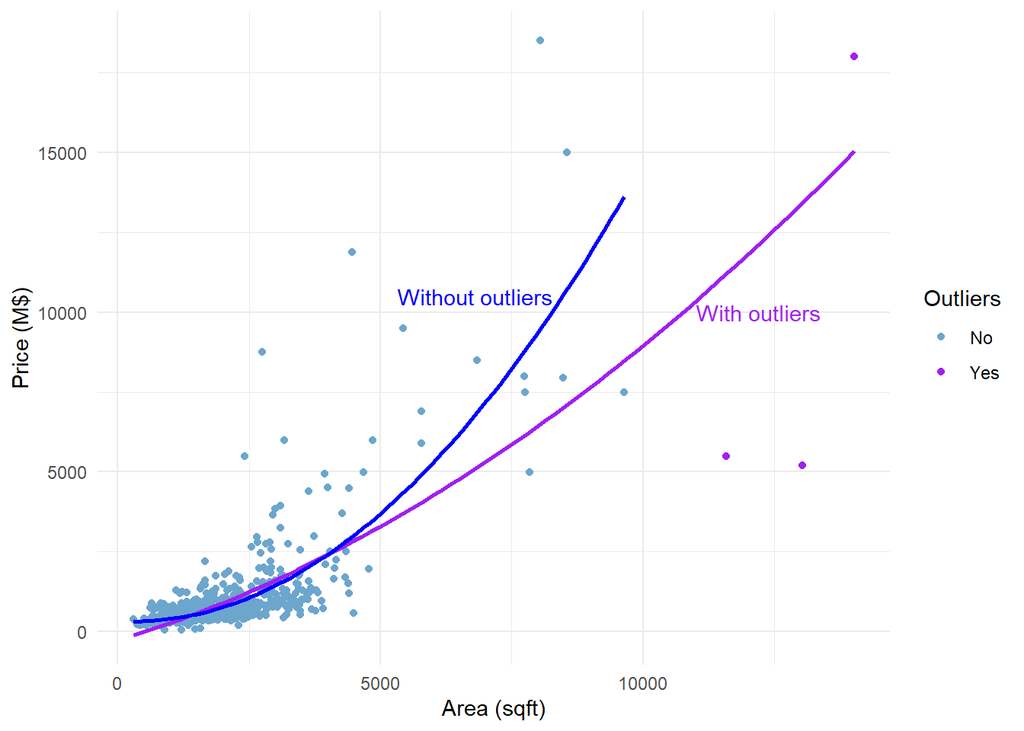

```r
# One way
ggplot(data = austin_clean, aes(y = price000s, x = area, color = factor(outlier))) +
  geom_point() + theme_minimal() +
  xlab("Area (sqft)") + ylab("Price (M$)") +
  scale_color_manual("Outliers", values = c("skyblue3","purple"), labels = c("No","Yes")) +
  geom_smooth(method = 'lm',formula = y ~ poly(x, 2), color = "purple", se = FALSE) +
  geom_smooth(data = austin_wo_outliers, aes(y = price000s, x = area),
              method = 'lm',formula = y ~ poly(x, 2), color = "blue", se = FALSE) +
  annotate("text", label = "Without outliers", x = 6800, y = 10500, color = "blue") + #Add annotations to the plot
  annotate("text", label = "With outliers", x = 12200, y = 10000, color = "purple")
```

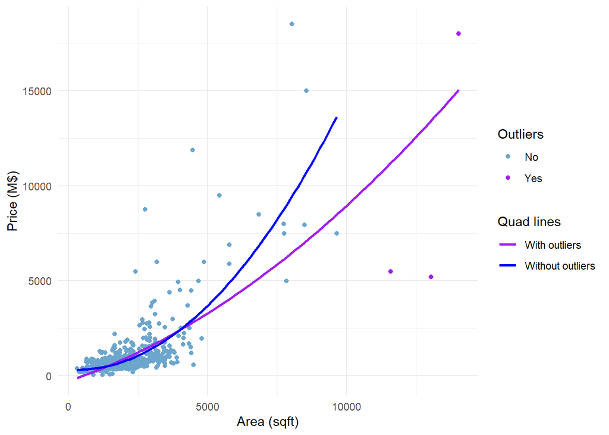

```r
# Another way
ggplot(data = austin_clean, aes(y = price000s, x = area)) +
  geom_point(aes(fill = factor(outlier)), pch = 21, color = alpha("darkgrey",0)) + theme_minimal() +
  xlab("Area (sqft)") + ylab("Price (M$)") +
  scale_fill_manual("Outliers", values = c("skyblue3","purple"), labels = c("No","Yes")) +
  geom_smooth(aes(color = "With outliers"), method = 'lm',formula = y ~ poly(x, 2), se = FALSE) +
  geom_smooth(data = austin_wo_outliers, aes(y = price000s, x = area, color = "Without outliers"),
              method = 'lm',formula = y ~ poly(x, 2), se = FALSE) +
  scale_color_manual("Quad lines", values = c("purple","blue"), labels = c("With outliers","Without outliers"))
```

10 points: Creates the correct plot including: (1) highlights outliers vs non-outliers, (2) creates two quadratic regression lines (different colors), (3) uses correct labels for the axis, and (4) has at least one appropriate legend (for outliers or the lines).

8 points: Problems with one of the previous items.

6 points: Problems with two of the previous items.

4 points: Problems with three of the previous items.

0 point: Problems with all four items.

**5) Using the previous plot, what can you say about the relationship between area and price for the complete sample compared to the sample without outliers? Highlight one main difference.** (4 points)

Answer:

We can observe that the relationship is less pronounced and seems more linear when we use the complete sample. However, when we take out the outliers, the association becomes stronger and appears more quadratic.

4 points: Highlights one specific difference (e.g. shape, steepnesss, changes from >5,000 sft)

2 points: Highlights a difference, but has some issues with it.

0 points: Any other case.

**6) Given all the analyses that you have conducted, can you say your original results (2.2) are robust to outliers?** (3 points)

Answer:

No, because we can see that there is a magnitude change in the association and a significance change in one of my coefficients.

# Task 3 - Targeting donations

You are working for a non-profit organization and you are in charge of getting donations. You are asked to target potential donors that make over $50,000 in income, and they provide a dataset of potential donors:

```r
donors <- read.csv("https://raw.githubusercontent.com/maibennett/sta235/main/exampleSite/content/Assignments/Homework/HW2/data/income.csv")
```

Some of the variables in the dataset are the following:

- `age`: Age in years
- `workclass`: Games played.
- `education`: Education (highest level)
- `education_num`: Education (years)
- `marital_status`: Marital status
- `occupation`: Occupation (category)
- `race`: Race (category)
- `gender`: Gender (male or female)
- `hours_per_week`: Hours worked in a week
- `native_country`: Country of birth
- `income_over_50k`: Income is greater than $50k or equal or less than $50k

**1a) Create a binary variable for income $> \%50k$ (1) and $\leq\$50k$ (0), called `income50`.** (2 points)

Answer:

```r
donors <- donors %>% mutate(income50 = ifelse(income_over_50k==">50K", 1, 0))

donors %>% select(income50) %>% table(.)
```

[output not shown]

2 points: Creates the new variable correctly

0 points: Does not create the variable correctly

**1b) How many observations do you have over $50K?** (1 point)

Answer: We have 7841 observations with an income over $50K (1) and 24720 observations with an income equal or under $50K.

**2a) Create a categorical variable (factor variable), called `race3`, that has three categories: (1) White, (2) Black, and (3) All others. In this case, all observations that are not in the first or second category should be in the third one.** *Hint: You can create first a numeric variable, and then transform that into a factor variable. Don’t forget to use labels for your factor variable!* (6 points)

Answer:

```r
donors <- donors %>% mutate(race3 = ifelse(race=="White",1,
                                           ifelse(race=="Black",2,3))) %>%
  mutate(race3 = factor(race3, labels = c("White", "Black", "All others")))

donors %>% select(race3) %>% table(.)
```

[output not shown]

3 points: Creates a factor variable with correct labels

2 points: Creates a factor variable, but doesn’t include labels/ Creates a factor variable, but labels are not in the correct order (e.g. All others is 1)/ Creates a character variable and not a factor.

1 point: Only creates a numeric variable.

0 points: Any other case.

**2b) How many observations do you have in each category?** (3 points)

Answer:

In this case, we have 27816 observations that are “White”, 3124 that are “Black”, and 1621 observations from other races.

1 point per correct observations in each category

**3) Run a regression using `income50` as a dependent variable and `race3`, `education_num`, and `gender` as covariates** *Note: You will need to use factor(gender) in this case*

**3a) Show your code** (3 points)

```r
library(estimatr)
options(scipen = 0)

lm1 <- lm_robust(income50 ~ race3 + education_num + factor(gender), data = donors)

summary(lm1)
```

```
##
## Call:
## lm_robust(formula = income50 ~ race3 + education_num + factor(gender),
##     data = donors)
##
## Standard error type:  HC2
##
## Coefficients:
##                    Estimate Std. Error t value  Pr(>|t|) CI Lower CI Upper
## (Intercept)        -0.42937  0.0084887 -50.581 0.000e+00 -0.44601 -0.41273
## race3Black         -0.06124  0.0061812  -9.908 4.146e-23 -0.07336 -0.04913
## race3All others    -0.04829  0.0097199  -4.968 6.804e-07 -0.06734 -0.02924
## education_num       0.05483  0.0008366  65.537 0.000e+00  0.05319  0.05647
## factor(gender)Male  0.18791  0.0041739  45.020 0.000e+00  0.17973  0.19609
##                       DF
## (Intercept)        32556
## race3Black         32556
## race3All others    32556
## education_num      32556
## factor(gender)Male 32556
##
## Multiple R-squared:  0.1594 ,    Adjusted R-squared:  0.1593
## F-statistic:  1654 on 4 and 32556 DF,  p-value: < 2.2e-16
```

3 points: Correct regression and use of robust standard errors.

1 point: Correct regression but doesn’t use robust standard errors.

0 points: Any other case.

**3b) Interpret the coefficient for `education_num`** (3 points)

An additional year of education is associated to an average increase in the probability of having an income over $50K of 5.5 percentage points, holding other variables constant.

3 points: Correct point estimate, units, and wording (“average”, “holding other variables constant”)

2 point: Correct point estimate, units, but missing some wording

1 point: Incorrect point estimate and units

0 points: Any other case.

**3c) Is the coefficient for being male statistically significant in this model?** (1 points)

Answer:

The coefficient is statistically significant,

**3d-f) What is the point estimate, standard error, and t-value for `gender` in this model?** (1 point each)

The point estimate is 0.19. The standard error for the estimate is 0.0042 and the t-value is 45.02

**4) You think that the relationship between the probability of having income over $50K and age is not linear, so you decide to include a quadratic term. Your boss also mentions that she thinks that these associations are different between men and women. With these two things in mind, you decide to run the following model:**

$$income50 = \beta_0 + \beta_1 age +
\beta_2 age^2 + \beta_3 female + \beta_4 female\times age + \beta_5
female\times age^2 + \varepsilon$$

**4a) Show your code** *(Hint: You will need to create the `female` variable)* (5 points)

```r
donors <- donors %>% mutate(female = ifelse(gender=="Female", 1, 0))

lm2 <- lm_robust(income50 ~ age*female + I(age^2)*female, data = donors)

summary(lm2)
```

```
##
## Call:
## lm_robust(formula = income50 ~ age * female + I(age^2) * female,
##     data = donors)
##
## Standard error type:  HC2
##
## Coefficients:
##                   Estimate Std. Error t value   Pr(>|t|)   CI Lower   CI Upper
## (Intercept)     -0.8246197  1.829e-02  -45.08  0.000e+00 -0.8604764 -0.7887630
## age              0.0494502  1.019e-03   48.53  0.000e+00  0.0474532  0.0514473
## female           0.4983840  2.465e-02   20.22  2.288e-90  0.4500759  0.5466921
## I(age^2)        -0.0004728  1.244e-05  -37.99 5.060e-309 -0.0004971 -0.0004484
## age:female      -0.0284973  1.413e-03  -20.17  5.922e-90 -0.0312660 -0.0257285
## female:I(age^2)  0.0002563  1.725e-05   14.86  9.033e-50  0.0002225  0.0002901
##                    DF
## (Intercept)     32555
## age             32555
## female          32555
## I(age^2)        32555
## age:female      32555
## female:I(age^2) 32555
##
## Multiple R-squared:  0.1473 ,    Adjusted R-squared:  0.1471
## F-statistic:  1506 on 5 and 32555 DF,  p-value: < 2.2e-16
```

5 points: Creates variable correctly, runs the right regression, and uses robust standard errors.

3 points: Problem with the regression formula OR creating the variable, but uses robust standard errors.

2 points: Doesn’t use robust standard errors.

0 points: Any other case.

**4b) How does the probability of having an income over $50K change for a male that goes from 30 to 31 years?** (5 points) (Round your answer to 2 decimals)

```r
age_0 = 30

change_male = lm2$coefficients['age'] + 2*lm2$coefficients['I(age^2)']*age_0
```

Increasing the age of a male from 30 to 31 is associated to an average increase in the probability of having an income over $50K of 2.11 percentage points.

**4c) How does the probability of having an income over $50K change for a female that goes from 30 to 31 years?** (7 points) (Round your answer to 2 decimals)

```r
age_0 = 30

change_female = lm2$coefficients['age'] + lm2$coefficients['age:female'] + 2*(lm2$coefficients['I(age^2)'] + lm2$coefficients['female:I(age^2)'])*age_0
```

Increasing the age of a female from 30 to 31 is associated to an average increase in the probability of having an income over $50K of 0.80 percentage points.

7 points: Correct interpretation (wording), correct point estimate, and correct units.

6 points: Overall correct, but uses “holding other variables constant”/ doesn’t include “average” or similar.

5 points: Overall correct, but units are not correct (e.g. uses percentage instead of percentage points).

3 points: Wording is correct, including units, but point estimate is not.

0 points: Any other case.

**4d) Interpret the intercept. Does it have a practical interpretation?** (3 points)

Answer:

The probability of a male with age 0 of having an income over 50K is, on average, -0.82. This intercept doesn’t have a practical interpretation.

3 points: Interprets the intercept correctly, including showing the point estimate, and setting all variables to 0 (explaining what that means). Explains that the itnercept doesn’t have a practical interpretation.

2 points: Doesn’t include the point estimate/ Doesn’t explain what setting covariates to 0 mean in this context/ Doesn’t say something about the practical interpretation.

1 points: Fails in two of the previous points OR says “holding other variables constant”.

0 points: Any other case.

**5) Which of the following statements are TRUE:** (2 points)

1. According to our model in 3.3, the difference in the probability of having an income over $50K is not statistically significant between males and females, holding other things constant.
2. Looking at our model in 3.4, for males, there are diminishing returns to age on the probability of making over $50K in income.
3. According to our model in 3.3, holding education and gender constant, black individuals have, on average, a lower probability of having an income over $50K compared to white individuals.
4. The intercept in model 3.4 represents the average probability for males having an income over $50K
5. If we wanted to predict the probability of a female having an income over $50K, we should use the model in 3.4.

Answer: B and C.